# Análisis estadístico del ancho del fruto de piña

Ananas comosus L. Merr. - Variedad Golden MD-2

Author

Trabajo individual - Programación y Análisis de Datos

# Introducción

Este trabajo presenta el análisis estadístico del ancho del fruto de piña (*Ananas comosus* L. Merr.), utilizando datos de la investigación de Chacón Huamaní (2019).

Se evalúan siete tratamientos de fertilización con boro y potasio, distribuidos en cuatro bloques.

# Base de datos

La base organizada comprende 28 observaciones, correspondientes a siete tratamientos y cuatro bloques.

Datos organizados para el análisis

| Tratamiento | Bloque | Ancho promedio |
| --- | --- | --- |
| T1 | 1 | 13.900 |
| T1 | 2 | 13.575 |
| T1 | 3 | 13.825 |
| T1 | 4 | 13.000 |
| T2 | 1 | 12.675 |
| T2 | 2 | 12.650 |
| T2 | 3 | 13.850 |
| T2 | 4 | 12.600 |
| T3 | 1 | 13.575 |
| T3 | 2 | 13.125 |
| T3 | 3 | 13.250 |
| T3 | 4 | 13.250 |
| T4 | 1 | 14.375 |
| T4 | 2 | 13.500 |
| T4 | 3 | 13.475 |
| T4 | 4 | 13.250 |
| T5 | 1 | 14.375 |
| T5 | 2 | 13.875 |
| T5 | 3 | 14.525 |
| T5 | 4 | 13.075 |
| T6 | 1 | 13.625 |
| T6 | 2 | 13.175 |
| T6 | 3 | 13.225 |
| T6 | 4 | 13.525 |
| T7 | 1 | 13.675 |
| T7 | 2 | 13.750 |
| T7 | 3 | 13.825 |
| T7 | 4 | 13.700 |

# 1. Modelo estadístico

Se emplea un modelo de Diseño de Bloques Completos al Azar (DBCA), bajo la estructura experimental considerada para el análisis.

$$Y_{ij} = \mu + T_i + B_j + \varepsilon_{ij}$$

# 2. Análisis de varianza (ANOVA)

Análisis de varianza del ancho del fruto

|  | Fuente | gl | SC | CM | F | Valor p |
| --- | --- | --- | --- | --- | --- | --- |
| tratamiento | tratamiento | 6 | 2.6402 | 0.4400 | 3.2548 | 0.0240 |
| bloque | bloque | 3 | 1.4551 | 0.4850 | 3.5876 | 0.0342 |
| Residuals | Residuals | 18 | 2.4335 | 0.1352 | NA | NA |

## Interpretación del ANOVA

El análisis de varianza mostró diferencias estadísticamente significativas entre los tratamientos (p = 0.0240), considerando un nivel de significancia del 5 %.

También se identificaron diferencias significativas entre bloques (p = 0.0342).

# 3. Comparación de medias de Tukey

Se aplicó la prueba de Tukey al 5 % para identificar diferencias entre las medias de los tratamientos.

Comparación de medias de Tukey al 5 %

|  | Tratamiento | Media | Grupo |
| --- | --- | --- | --- |
| T5 | T5 | 13.9625 | a |
| T7 | T7 | 13.7375 | ab |
| T4 | T4 | 13.6500 | ab |
| T1 | T1 | 13.5750 | ab |
| T6 | T6 | 13.3875 | ab |
| T3 | T3 | 13.3000 | ab |
| T2 | T2 | 12.9438 | b |

## Interpretación de Tukey

El tratamiento T5 presentó el mayor ancho promedio del fruto (13.9625), mientras que T2 presentó el menor promedio (12.94375).

Según la prueba de Tukey, T5 y T2 mostraron una diferencia estadísticamente significativa.

Los demás tratamientos compartieron letras de agrupación con ambos tratamientos.

# 4. Gráfico de resultados

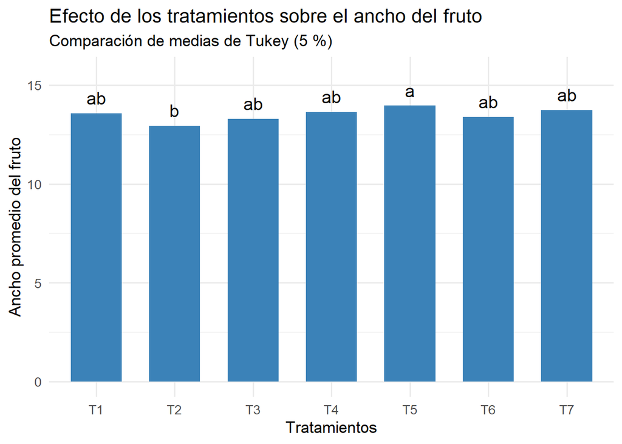

**Nota:** Las medias que comparten al menos una letra no presentan diferencias significativas según Tukey al 5 %.

# 5. Verificación de supuestos

Pruebas de diagnóstico estadístico

| Prueba | Valor_p |
| --- | --- |
| Shapiro-Wilk | 0.9884 |
| Fligner-Killeen | 0.2818 |

La prueba de Shapiro-Wilk obtuvo un valor p de 0.9884. Por ello, no se rechazó la hipótesis de normalidad de los residuos.

La prueba de Fligner-Killeen obtuvo un valor p de 0.2818, por lo que no se detectó evidencia significativa de heterogeneidad de varianzas entre tratamientos.

# 6. Conclusiones

El análisis de varianza identificó diferencias estadísticamente significativas entre los tratamientos evaluados para el ancho del fruto.

El tratamiento T5 presentó el mayor promedio, mientras que T2 obtuvo el menor.

La comparación de Tukey identificó una diferencia estadísticamente significativa entre T5 y T2.

Los resultados corresponden al modelo estadístico aplicado y deben interpretarse considerando el diseño experimental original y la independencia de las unidades experimentales.

# Referencia